# Technical details on linear regression for proteomics

Lieven Clement

statOmics, Ghent University (https://statomics.github.io)

# 1 Preamble

Read stored results for heart data

```r
library(tidyverse)
library(limma)
library(QFeatures)
library(msqrob2)
pe <- readRDS("peHeart.rds")
```

# 2 Linear regression

- Consider a vector of predictors $\mb{x}_i=(x_1,\ldots,x_{p-1})$ and
- a real-valued response $Y_i$
- with $i = 1, \ldots, n$
- then the linear regression model can be written as
  $$Y_i=f(\mb{x}) +\epsilon=\beta_0+\sum\limits_{j=1}^{p-1} x_{ij}\beta + \epsilon_i$$
  with i.i.d. $\epsilon_i\sim N(0,\sigma^2)$
- $n$ observations $(\mb{x}_1,y_1) \ldots (\mb{x}_n,y_n)$
- Regression in matrix notation
  $$\mb{Y}=\mb{X\beta} + \mb{\epsilon}$$
  with $\mb{Y}=\left[\begin{array}{c}y_1\\ \vdots\\y_n\end{array}\right]$, $\mb{X}=\left[\begin{array}{cccc} 1&x_{11}&\ldots&x_{1p-1}\\ \vdots&\vdots&&\vdots\\ 1&x_{n1}&\ldots&x_{np-1} \end{array}\right]$, $\mb{\beta}=\left[\begin{array}{c}\beta_0\\ \vdots\\ \beta_{p-1}\end{array}\right]$ and $\mb{\epsilon}=\left[\begin{array}{c} \epsilon_1 \\ \vdots \\ \epsilon_n\end{array}\right]$

## 2.1 Least Squares (LS)

- Minimize the residual sum of squares
  $$\begin{eqnarray*}
  RSS(\mb{\beta})&=&\sum\limits_{i=1}^n e^2_i\\
  &=&\sum\limits_{i=1}^n \left(y_i-\beta_0-\sum\limits_{j=1}^p x_{ij}\beta_j\right)^2
  \end{eqnarray*}$$
- or in matrix notation
  $$\begin{eqnarray*}
  RSS(\mb{\beta})&=&(\mb{Y}-\mb{X\beta})^T(\mb{Y}-\mb{X\beta})\\
  &=&\Vert \mb{Y}-\mb{X\beta}\Vert^2
  \end{eqnarray*}$$
  with the $L_2$-norm of a $p$-dim. vector $v$ $\Vert \mb{v} \Vert=\sqrt{v_1^2+\ldots+v_p^2}$ -[$\rightarrow$] $\hat{\mb{\beta}=\text{argmin}_\beta \Vert \mb{Y}-\mb{X\beta}\Vert^2$}

### 2.1.1 Minimize RSS

$$\begin{array}{ccc}
\frac{\partial RSS}{\partial \mb{\beta}}&=&\mb{0}\\\\
\frac{(\mb{Y}-\mb{X\beta})^T(\mb{Y}-\mb{X\beta})}{\partial \mb{\beta}}&=&\mb{0}\\\\
-2\mb{X}^T(\mb{Y}-\mb{X\beta})&=&\mb{0}\\\\
\mb{X}^T\mb{X\beta}&=&\mb{X}^T\mb{Y}\\\\
\hat{\mb{\beta}}&=&(\mb{X}^T\mb{X})^{-1}\mb{X}^T\mb{Y}
\end{array}$$

#### 2.1.1.1 heart example

```r
y <- assay(pe[["proteinRobust"]])[2,]
fit <- lm(y ~ location*tissue + patient, data = colData(pe), x = TRUE)
head(fit$x,4)
```

```
##               (Intercept) locationR tissueV patient4 patient8 locationR:tissueV
## Intensity.LA3           1         0       0        0        0                 0
## Intensity.LA4           1         0       0        1        0                 0
## Intensity.LA8           1         0       0        0        1                 0
## Intensity.LV3           1         0       1        0        0                 0
```

The model matrix can also be obtained without fitting the model:

```r
X <- model.matrix(~ location * tissue + patient, colData(pe))
head(X,4)
```

```
##               (Intercept) locationR tissueV patient4 patient8 locationR:tissueV
## Intensity.LA3           1         0       0        0        0                 0
## Intensity.LA4           1         0       0        1        0                 0
## Intensity.LA8           1         0       0        0        1                 0
## Intensity.LV3           1         0       1        0        0                 0
```

Least squares:

```r
betas <- solve(t(X)%*%X) %*% t(X) %*% y
cbind(fit$coef, betas)
```

```
##                          [,1]        [,2]
## (Intercept)       26.57559360 26.57559360
## locationR          0.20636497  0.20636497
## tissueV            0.12756675  0.12756675
## patient4           0.30592435  0.30592435
## patient8          -0.33432636 -0.33432636
## locationR:tissueV -0.04130843 -0.04130843
```

### 2.1.2 Variance Estimator?

$$\begin{array}{ccl}
\hat{\boldmath{\Sigma}}_{\hat{\mb{\beta}}}
&=&\text{var}\left[(\mb{X}^T\mb{X})^{-1}\mb{X}^T\mb{Y}\right]\\\\
&=&(\mb{X}^T\mb{X})^{-1}\mb{X}^T\text{var}\left[\mb{Y}\right]\mb{X}(\mb{X}^T\mb{X})^{-1}\\\\
&=&(\mb{X}^T\mb{X})^{-1}\mb{X}^T(\mb{I}\sigma^2)\mb{X}(\mb{X}^T\mb{X})^{-1}
\\\\
&=&(\mb{X}^T\mb{X})^{-1}\mb{X}^T\mb{I}\quad\mb{X}(\mb{X}^T\mb{X})^{-1}\sigma^2\\\\
%\hat{\boldmath{\Sigma}}_{\hat{\mb{\beta}}}&=&(\mb{X}^T\mb{X})^{-1}\mb{X}^T\var\left[\mb{Y}\right](\mb{X}^T\mb{X})^{-1}\mb{X}\\
&=&(\mb{X}^T\mb{X})^{-1}\mb{X}^T\mb{X}(\mb{X}^T\mb{X})^{-1}\sigma^2\\\\
&=&(\mb{X}^T\mb{X})^{-1}\sigma^2
\end{array}$$

#### 2.1.2.1 heart example

```r
summary(fit)$cov.unscaled * sigma(fit)^2
```

```
##                   (Intercept)     locationR       tissueV      patient4
## (Intercept)         0.3938774 -2.625849e-01 -2.625849e-01 -1.969387e-01
## locationR          -0.2625849  5.251699e-01  2.625849e-01  1.145024e-16
## tissueV            -0.2625849  2.625849e-01  5.251699e-01  7.663178e-17
## patient4           -0.1969387  1.145024e-16  7.663178e-17  3.938774e-01
## patient8           -0.1969387  1.868024e-16  1.489318e-16  1.969387e-01
## locationR:tissueV   0.2625849 -5.251699e-01 -5.251699e-01 -5.227534e-17
##                        patient8 locationR:tissueV
## (Intercept)       -1.969387e-01      2.625849e-01
## locationR          1.868024e-16     -5.251699e-01
## tissueV            1.489318e-16     -5.251699e-01
## patient4           1.969387e-01     -5.227534e-17
## patient8           3.938774e-01     -2.473696e-16
## locationR:tissueV -2.473696e-16      1.050340e+00
```

```r
n <- nrow(X)
p <- ncol(X)
mse <- sum((y-X%*%betas)^2)/(n-p)
SigmaBeta <- solve(t(X)%*%X) * mse
SigmaBeta
```

```
##                   (Intercept)  locationR    tissueV   patient4   patient8
## (Intercept)         0.3938774 -0.2625849 -0.2625849 -0.1969387 -0.1969387
## locationR          -0.2625849  0.5251699  0.2625849  0.0000000  0.0000000
## tissueV            -0.2625849  0.2625849  0.5251699  0.0000000  0.0000000
## patient4           -0.1969387  0.0000000  0.0000000  0.3938774  0.1969387
## patient8           -0.1969387  0.0000000  0.0000000  0.1969387  0.3938774
## locationR:tissueV   0.2625849 -0.5251699 -0.5251699  0.0000000  0.0000000
##                   locationR:tissueV
## (Intercept)               0.2625849
## locationR                -0.5251699
## tissueV                  -0.5251699
## patient4                  0.0000000
## patient8                  0.0000000
## locationR:tissueV         1.0503398
```

```r
range(SigmaBeta - summary(fit)$cov.unscaled * sigma(fit)^2)
```

```
## [1] -4.773959e-15  9.103829e-15
```

```r
data.frame(summary(fit)$coef[,1:2], betas = betas, seBetas = diag(SigmaBeta)^.5)
```

```
##                      Estimate Std..Error       betas   seBetas
## (Intercept)       26.57559360  0.6275965 26.57559360 0.6275965
## locationR          0.20636497  0.7246861  0.20636497 0.7246861
## tissueV            0.12756675  0.7246861  0.12756675 0.7246861
## patient4           0.30592435  0.6275965  0.30592435 0.6275965
## patient8          -0.33432636  0.6275965 -0.33432636 0.6275965
## locationR:tissueV -0.04130843  1.0248609 -0.04130843 1.0248609
```

## 2.2 Contrasts

When we assess a contrast we assess a linear combination of model parameters:

$$H_0: \mb{L^T\beta} = 0 \text{ vs } H_1: \mb{L^T\beta} \neq 0$$

Estimator of Contrast?

$$\mb{L}^T\hat{\mb{\beta}}$$

Variance?

$$\boldsymbol{\Sigma}_{\mb{L}\hat{\boldsymbol{\beta}}}=\mb{L}^T\boldsymbol{\Sigma}_{\hat{\boldsymbol{\beta}}}\mb{L}$$

### 2.2.1 heart example

```r
L <- makeContrast(
  c(
    "tissueV = 0",
    "tissueV + locationR:tissueV = 0",
    "tissueV + 0.5*locationR:tissueV = 0","locationR:tissueV = 0"),
  parameterNames =
    rowData(pe[["proteinRobust"]])$msqrobModels[[2]] %>%
    getCoef %>%
    names
  )
L
```

```
##                   tissueV tissueV + locationR:tissueV
## (Intercept)             0                           0
## locationR               0                           0
## tissueV                 1                           1
## patient4                0                           0
## patient8                0                           0
## locationR:tissueV       0                           1
##                   tissueV + 0.5 * locationR:tissueV locationR:tissueV
## (Intercept)                                     0.0                 0
## locationR                                       0.0                 0
## tissueV                                         1.0                 0
## patient4                                        0.0                 0
## patient8                                        0.0                 0
## locationR:tissueV                               0.5                 1
```

```r
contrasts <- t(L) %*% betas
SigmaContrasts <- t(L) %*% SigmaBeta %*% L
seContrasts <- SigmaContrasts %>%
  diag %>%
  sqrt
```

Comparison with lm and glht results

```r
library(multcomp)
fitGlht <- glht(fit, linfct = t(L))
summary(fitGlht, test = adjusted("none"))
```

```
##
##   Simultaneous Tests for General Linear Hypotheses
##
## Fit: lm(formula = y ~ location * tissue + patient, data = colData(pe),
##     x = TRUE)
##
## Linear Hypotheses:
##                                        Estimate Std. Error t value Pr(>|t|)
## tissueV == 0                            0.12757    0.72469   0.176    0.866
## tissueV + locationR:tissueV == 0        0.08626    0.72469   0.119    0.909
## tissueV + 0.5 * locationR:tissueV == 0  0.10691    0.51243   0.209    0.842
## locationR:tissueV == 0                 -0.04131    1.02486  -0.040    0.969
## (Adjusted p values reported -- none method)
```

```r
data.frame(contrasts, seContrasts)
```

```
##                                     contrasts seContrasts
## tissueV                            0.12756675   0.7246861
## tissueV + locationR:tissueV        0.08625832   0.7246861
## tissueV + 0.5 * locationR:tissueV  0.10691253   0.5124304
## locationR:tissueV                 -0.04130843   1.0248609
```

```r
seContrasts / seContrasts[1]
```

```
##                           tissueV       tissueV + locationR:tissueV
##                         1.0000000                         1.0000000
## tissueV + 0.5 * locationR:tissueV                 locationR:tissueV
##                         0.7071068                         1.4142136
```

```r
sqrt(2)
```

```
## [1] 1.414214
```

```r
1/sqrt(2)
```

```
## [1] 0.7071068
```

### 2.2.2 t-tests

- When the assumptions of the linear model hold
  $$\hat{\mb{\beta}} \sim MVN\left[\mb{\beta},\left(\mb{X}^T\mb{X}\right)^{-1}\sigma^2\right]$$
- Hence,
  $$\mb{L}^T\hat{\mb{\beta}} \sim MVN\left[\mb{L}^T\mb{\beta},\mb{L}^T\left[\left(\mb{X}^T\mb{X}\right)^{-1}\sigma^2\right]\mb{L}\right]$$
- We estimate $\sigma^2$ by MSE
  $$\hat{\sigma}^2=\frac{\mb{e}^T\mb{e}}{n-p} \rightarrow \hat{\boldsymbol{\Sigma}}_{\hat{\boldsymbol{\beta}}}=\left(\mb{X}^T\mb{X}\right)^{-1}\hat\sigma^2$$
- When we test one contrast at the time (e.g. the $k^\text{th}$ contrast) the statistic reduces to

$$T=\frac{\mb{L}_k^T\hat{\boldsymbol{\beta}}}{\sqrt{\left(\mb{L}^T_k\hat{\boldsymbol{\Sigma}}_{\hat{\boldsymbol{\beta}}}\mb{L}_k\right)}} \underset{H_0}{\sim} t_{n-p}$$
follows a t distribution with n-p degrees of freedom under $H_0: \mb{L}^T_k\hat{\boldsymbol{\beta}}=0$

#### 2.2.2.1 heart example

```r
tContrasts <- contrasts/seContrasts
pContrasts <- pt(abs(tContrasts),
  df = n - p,
  lower.tail = FALSE) * 2
```

Comparison with lm and glht results

```r
summary(fitGlht, test = adjusted("none"))
```

```
##
##   Simultaneous Tests for General Linear Hypotheses
##
## Fit: lm(formula = y ~ location * tissue + patient, data = colData(pe),
##     x = TRUE)
##
## Linear Hypotheses:
##                                        Estimate Std. Error t value Pr(>|t|)
## tissueV == 0                            0.12757    0.72469   0.176    0.866
## tissueV + locationR:tissueV == 0        0.08626    0.72469   0.119    0.909
## tissueV + 0.5 * locationR:tissueV == 0  0.10691    0.51243   0.209    0.842
## locationR:tissueV == 0                 -0.04131    1.02486  -0.040    0.969
## (Adjusted p values reported -- none method)
```

```r
data.frame(contrasts, seContrasts, tContrasts, pContrasts)
```

```
##                                     contrasts seContrasts  tContrasts
## tissueV                            0.12756675   0.7246861  0.17603036
## tissueV + locationR:tissueV        0.08625832   0.7246861  0.11902853
## tissueV + 0.5 * locationR:tissueV  0.10691253   0.5124304  0.20863814
## locationR:tissueV                 -0.04130843   1.0248609 -0.04030638
##                                   pContrasts
## tissueV                            0.8660611
## tissueV + locationR:tissueV        0.9091380
## tissueV + 0.5 * locationR:tissueV  0.8416333
## locationR:tissueV                  0.9691566
```

### 2.2.3 Omnibus test

- We can also assess all contrasts simultaneously with the omnibus null hypothesis:
  $$H_0: $\mb{L}^T\hat{\mb{\beta}}=\mb{0}$$
- Statistic
  $$\mb{F}=\hat{\mb{\beta}}^T\mb{L}\left(\mb{L}^T\hat{\boldsymbol{\Sigma}}_{\hat{\boldsymbol{\beta}}}\mb{L}\right)^{-1}\mb{L}^T\hat{\mb{\beta}}/n_c \underset{H_0}{\sim} F_{r,n-p}$$
  follows an F distribution with $n_c$ and n-p degrees of freedom under the omnibus null hypothesis.
- Note, that $n_c$ equals the number of contrasts, and
- $\mb{L}$ is assumed to be full rank

If the matrix is not full rank, but has rank $r < n_c$ - i.e. some of the contrasts can be written as linear combinations of other contrasts, - the inverse of the variance covariance matrix of the contrasts does not exist - we can then decompose L in $r$ orthogonal contrasts $\mb{Q}$ with
$$Q_j^T Q_k^T = \delta_{jk},$$

- $j,k \in 1,\ldots,r$,
- $\delta{jk} = 0$ and if $j\neq k$ $\delta{jk} = 1$
- which can be done using the QR decomposition
- We can that assess the omnibus null hypothesis using the statistic:
  $$\mb{F}=\hat{\mb{\beta}}^T\mb{Q}_r\left(\mb{Q}^T_r\hat{\boldsymbol{\Sigma}}_{\hat{\boldsymbol{\beta}}}\mb{Q}_r\right)^{-1}\mb{Q}^T_r\hat{\mb{\beta}}/r \underset{H_0}{\sim} F_{r,n-p}$$

#### 2.2.3.1 Heart example

```r
try(solve(SigmaContrasts))
```

```
## Error in solve.default(SigmaContrasts) :
##   Lapack routine dgesv: system is exactly singular: U[3,3] = 0
```

- We cannot invert the variance matrix of the contrasts!
- Indeed, the contrasts are linear combinations of two parameters and the contrast matrix $\mb{L}$ will thus have rank 2
- We calculate orthogonal contrasts:

```r
qrL <- qr(L)
r <- qrL$rank
r
```

```
## [1] 2
```

```r
Q <- qr.Q(qrL)[,1:r]
rownames(Q) <- rownames(L)
Q
```

```
##                   [,1] [,2]
## (Intercept)          0    0
## locationR            0    0
## tissueV             -1    0
## patient4             0    0
## patient8             0    0
## locationR:tissueV    0   -1
```

- Q is orthonormal

```r
t(Q)%*%Q
```

```
##      [,1] [,2]
## [1,]    1    0
## [2,]    0    1
```

Exploring Q shows that assessing the omnibus hypothesis is thus equivalent to assessing if the null hypothesis that
$$H_0: \beta_\text{tissue} = \beta_\text{tissue:location} = 0$$

```r
est <- t(Q) %*% betas
SigmaEst <- t(Q) %*% SigmaBeta %*% Q
Fstat <- t(est) %*% solve(SigmaEst) %*% est / r
pOmnibus <- pf(Fstat, r, p, lower.tail = FALSE)
```

- Comparison with lm results
- We can assess the omnibus hypothesis also by comparing two models
  - model with location, tissue, location - tissue interaction and patient effect
  - null model: model with location and patient effect

```r
fit0 <- lm(y ~ location + patient, colData(pe))
anova(fit, fit0)
```

```
## Analysis of Variance Table
##
## Model 1: y ~ location * tissue + patient
## Model 2: y ~ location + patient
##   Res.Df    RSS Df Sum of Sq      F Pr(>F)
## 1      6 4.7265
## 2      8 4.7621 -2 -0.035571 0.0226 0.9778
```

```r
Fstat
```

```
##            [,1]
## [1,] 0.02257724
```

```r
pOmnibus
```

```
##           [,1]
## [1,] 0.9777584
```

# 3 Robust regression

- With msqrob2 we perform robust regression to estimate the model parameters of the regression model
- No normality assumption needed
- Robust fit minimises the maximal bias of the estimators
- CI and statistical tests are based on asymptotic theory
- If $\epsilon$ is normal, the M-estimators have a high efficiency!
- ordinary least squares (OLS): minimize loss function
  $$\sum\limits_{i=1}^n (y_i-\mb{x}_i^T\mb{\beta})^2$$
- M-estimation: minimize loss function
  $$\sum\limits_{i=1}^n \rho\left(y_i-\mb{x}_i^T\mb{\beta}\right)$$
  with
  - $\rho$ is symmetric, i.e. $\rho(z)=\rho(-z)$
  - $\rho$ has a minimum at $\rho(0)=0$, is positive for all $z\neq 0$
  - $\rho(z)$ increases as $\vert z\vert$ increases

The estimator $\hat{\mu}$ is also the solution to the equation
$$\sum_{i=1}^n \Psi(y_i - \mb{x}_i\mb{\beta}) =0,$$
where $\Psi$ is the derivative of $\rho$. For $\hat{\beta}$ possessing the robustness property, $\Psi$ should be bounded. Example: least squares

$\rho(z) = z^2$, and thus $\Psi(z)=2z$ (unbounded!). $\hat{\mb{\beta}}$ is the solution of
$$\sum_{i=1}^n 2 \mb{x}_i (y_i - \mb{x}_i^T\mb{\beta}) = 0 \text{ or } \hat{\mb{\beta}} = (\mb{X}^T\mb{X})^{-1}\mb{X}\mb{y}$$
with $\mb{X}=[\mb{x}_1 \ldots \mb{x}_G]^T$

When a location and a scale parameter, say $\sigma$, have to be estimated simultaneously, we write
$$(\hat{\mb{\beta}},\hat{\sigma}) = \text{ArgMin}_{\mb{\beta},\sigma} \sum_{i=1}^n \rho\left(\frac{y_i - \mb{x}_i^T\mb{\beta}}{\sigma}\right)
\text{ and } \sum_{i=1}^n \Psi\left(\frac{y_i - \mb{x}_i^T\mb{\beta}}{\sigma}\right) =0.$$

Define $u_i = \frac{y_i - \mb{x}_i^T\mb{\beta}}{\sigma}$. The last estimation equation is equivalent to
$$\sum_{i=1}^n w(u_i) u_i = 0 ,$$
with weight function $w(u)=\Psi(u)/u$. This is the typical form that appears when solving the *iteratively reweighted least squares problem*,
$$(\hat{\mb{\beta}},\hat{\sigma}) = \text{ArgMin}_{\mu,\sigma} \sum_{i=1}^n w(u_i^{(k-1)}) \left(u_i^{(k)}\right)^2 ,$$
where $k$ represents the iteration number.

## 3.1 Some Examples of Robust Functions

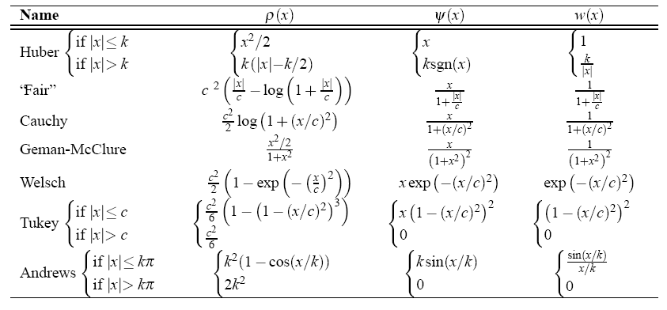

PhD thesis Bolstad 2004

## 3.2 The $\rho$ functions

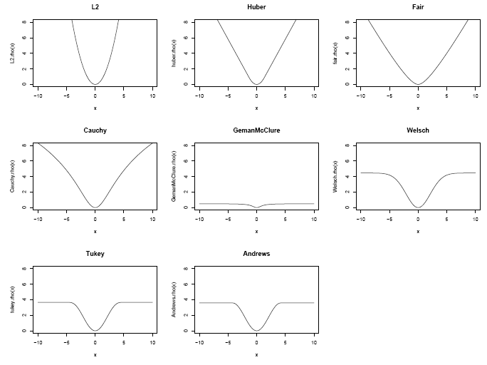

PhD thesis Bolstad 2004

### 3.2.1 Common $\Psi$-Functions

[figure not shown]

PhD thesis Bolstad 2004

### 3.2.2 Corresponding Weight Functions

[figure not shown]

PhD thesis Bolstad 2004

```r
library("MASS")
rfit <- rlm(y ~ location * tissue + patient, colData(pe), maxit=1)
```

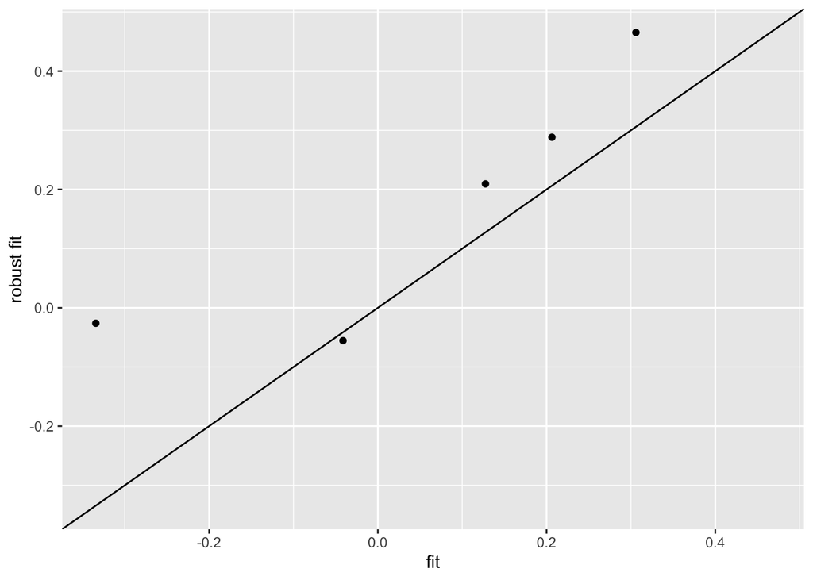

```r
qplot(fit$coefficient[-1],
  rfit$coefficient[-1],
  xlab="fit",
  ylab="robust fit") +
  geom_abline() +
  xlim(range(c(fit$coefficient[-1],rfit$coefficient[-1]))) +
  ylim(range(c(fit$coefficient[-1],rfit$coefficient[-1])))
```

```r
rfit$w
```

```
##  [1] 0.9516397 1.0000000 0.6628477 1.0000000 1.0000000 1.0000000 1.0000000
##  [8] 1.0000000 1.0000000 0.4805187 1.0000000 0.4344049
```

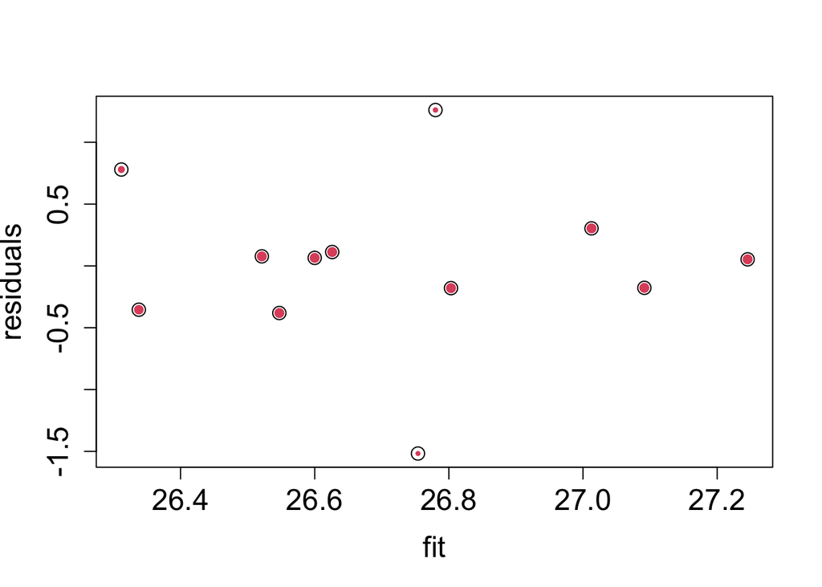

```r
plot(
  rfit$fitted,
  rfit$res,
  cex=rfit$w,
  pch=19,col=2,
  cex.lab=1.5,
  cex.axis=1.5,
  ylab="residuals",
  xlab="fit")
points(rfit$fitted, rfit$res , cex= 1.5)
```

```r
summary(fit)
```

```
##
## Call:
## lm(formula = y ~ location * tissue + patient, data = colData(pe),
##     x = TRUE)
##
## Residuals:
##      Min       1Q   Median       3Q      Max
## -1.29698 -0.32767  0.04041  0.24905  1.17251
##
## Coefficients:
##                   Estimate Std. Error t value Pr(>|t|)
## (Intercept)       26.57559    0.62760  42.345 1.16e-08 ***
## locationR          0.20636    0.72469   0.285    0.785
## tissueV            0.12757    0.72469   0.176    0.866
## patient4           0.30592    0.62760   0.487    0.643
## patient8          -0.33433    0.62760  -0.533    0.613
## locationR:tissueV -0.04131    1.02486  -0.040    0.969
## ---
## Signif. codes:  0 '***' 0.001 '**' 0.01 '*' 0.05 '.' 0.1 ' ' 1
##
## Residual standard error: 0.8876 on 6 degrees of freedom
## Multiple R-squared:  0.1687, Adjusted R-squared:  -0.524
## F-statistic: 0.2436 on 5 and 6 DF,  p-value: 0.9286
```

```r
summary(rfit)
```

```
##
## Call: rlm(formula = y ~ location * tissue + patient, data = colData(pe),
##     maxit = 1)
## Residuals:
##      Min       1Q   Median       3Q      Max
## -1.51703 -0.22326  0.05909  0.16009  1.26070
##
## Coefficients:
##                   Value   Std. Error t value
## (Intercept)       26.3378  0.5391    48.8585
## locationR          0.2883  0.6225     0.4631
## tissueV            0.2095  0.6225     0.3365
## patient4           0.4654  0.5391     0.8633
## patient8          -0.0261  0.5391    -0.0484
## locationR:tissueV -0.0555  0.8803    -0.0630
##
## Residual standard error: 0.4189 on 6 degrees of freedom
```

```r
rowData(pe[["proteinRobust"]])$msqrobModels[[2]] %>% getCoef
```

```
##       (Intercept)         locationR           tissueV          patient4
##       26.33779939        0.28826213        0.20946392        0.46536955
##          patient8 locationR:tissueV
##       -0.02608046       -0.05550111
```